# Modelo Obtención Log Odd-Ratio en Sujetos Control

```r
### Paquetes requeridos para el estudio ########
# Quitar el comentario e instalar
# install.packages("boot")
# install.packages("dplyr")
# install.packages("ggplot2")
# install.packages("gridExtra")
# install.packages("MASS")
# install.packages("fitdistrplus")
# install.packages("ggstatsplot")
# install.packages("tibble")
# install.packages("readr")
# install.packages("robustbase")
# install.packages("survival")
# install.packages("numDeriv")
# install.packages("optimx")
# install.packages("survival")


library(dplyr)
library(ggplot2)
library(gridExtra)
library(MASS)
library(fitdistrplus)
library(ggstatsplot)
library(tibble)
library(readr)
```

```r
# LImpiar todas variables temporales y dejar limpio el ambiente de trabajo
rm(list = ls())
```

# Modelo Causal Tractos Esquizofrenia

Funciones

```r
logistic.regression.or.ci <- function(regress.out, level = 0.95) {
  usual.output <- summary(regress.out)
  z.quantile <- stats::qnorm(1 - (1 - level) / 2)
  number.vars <- length(regress.out$coefficients)
  OR <- exp(regress.out$coefficients[-1])
  temp.store.result <- matrix(rep(NA, number.vars * 2), nrow = number.vars)
  for (i in 1:number.vars) {
    temp.store.result[i, ] <- summary(regress.out)$coefficients[i] +
      c(-1, 1) * z.quantile * summary(regress.out)$coefficients[i + number.vars]
  }
  intercept.ci <- temp.store.result[1, ]
  slopes.ci <- temp.store.result[-1, ]
  OR.ci <- exp(slopes.ci)
  output <- list(
    regression.table = usual.output, intercept.ci = intercept.ci,
    slopes.ci = slopes.ci, OR = OR, OR.ci = OR.ci
  )
  return(output)
}
```

## Etapa 1 - definición de los datos expuestos y no expuestos

Obtener datos de sujetos de control y estudio. Ajustar para su análisis posterior

```r
# confusoras DAG= "sl2l_qa", "sl2l_iso","ecpl_qa", "ecpl_iso","age", "gender_F",
# features predictoras = "sl2l_diameter","ccbd_diameter","ifol_diameter","ecpl_volume","tral_volume","sl2l_mean_length","ccbd_mean_length"

setwd("C:/hcgalvan/Repositorios/hcgalvan_project/data/union/End")
temp = gsub(".*target.*", "", readLines("integrado.csv"))
data<-read.table(text=temp, sep=",", header=TRUE)

t<-data.frame(data[,c("sl2l_diameter","ccbd_diameter","ifol_diameter","ecpl_volume","tral_volume","sl2l_mean_length","ccbd_mean_length","label","sl2l_qa", "sl2l_iso", "ccbd_iso", "ccbd_qa", "ifol_qa", "ifol_iso", "ecpl_qa", "ecpl_iso", "tral_qa", "tral_iso", "afsl_qa", "afsl_iso", "afsr_qa", "afsr_iso", "cfpl_iso", "cfpl_qa", "cfpr_iso", "cfpr_qa", "fatl_iso", "fatl_qa", "fatr_iso", "fatr_qa", "slfl_iso", "slfl_qa", "slfr_iso", "slfr_qa", "tral_iso", "tral_qa", "ufsl_iso", "ufsl_qa", "ufsr_iso", "ufsr_qa", "age", "gender_F")])

t$gend_F <- ifelse(t$gender_F == "True", 1, 0) #convierto en = o 1
t <- subset(t, select = -c(gender_F)) # Quito de tabla
```

### Creación de features expuestos y no expuestos

Definición de nuevas variables como Expuesto y no Expuesto obtenido del analisis de su real distribución empírica. Donde False = No Expuesto = 0; True = Expuesto = 1

```r
 #  Min. 1st Qu.  Median    Mean 3rd Qu.    Max.
 # 19.86   22.10   23.02   23.30   24.42   27.18
t<- t %>%
  mutate(sl2ldmExp = if_else((t$sl2l_diameter > 22.10 & t$sl2l_diameter < 24.42), 0, 1))
#21.73   26.07   28.18   28.29   30.23   32.90
t<- t %>%
  mutate(ccbdmExp = if_else((t$ccbd_diameter > 26.07 & t$ccbd_diameter < 30.23), 0, 1))
#11.70   14.68   15.91   15.73   16.51   19.64
t<- t %>%
  mutate(ifoldmExp = if_else((t$ifol_diameter > 14.68 & t$ifol_diameter < 16.51), 0, 1))
 #1785    6455    7407    7250    8918   10622
t<- t %>%
  mutate(ecplvlExp = if_else((t$ecpl_volume > 6455 & t$ecpl_volume < 8918), 0, 1))
#7780   12366   15988   15911   18004   26424
t<- t %>%
  mutate(tralvlExp = if_else((t$tral_volume > 12366 & t$tral_volume < 18004), 0, 1))
#65.44   72.18   75.69   76.94   80.61   88.53
t<- t %>%
  mutate(sl2lmlExp = if_else((t$sl2l_mean_length > 72.18 & t$sl2l_mean_length < 80.61), 0, 1))
  #99.87  112.62  117.22  117.47  123.81  131.73
t<- t %>%
  mutate(ccbdmlExp = if_else((t$ccbd_mean_length > 112.62 & t$ccbd_mean_length < 123.81), 0, 1))
```

```r
#par(mfrow = c(2, 2), mar = c(2, 2, 2, 2))
xtabs(~sl2ldmExp,t);xtabs(~ccbdmExp,t);xtabs(~ifoldmExp,t);xtabs(~ecplvlExp,t);xtabs(~tralvlExp,t);xtabs(~sl2lmlExp,t)
```

```
sl2ldmExp
 0  1
38 58
ccbdmExp
 0  1
47 49
ifoldmExp
 0  1
39 57
ecplvlExp
 0  1
42 54
tralvlExp
 0  1
43 53
sl2lmlExp
 0  1
47 49
```

```r
xtabs(~ccbdmlExp,t)
```

```
ccbdmlExp
 0  1
37 59
```

```r
##---------------------HACIENDO MINIMOS CALCULOS DE ODDS PARA OBSERVAR LOS DATOS ---------------------##
tx<-c()
########################
tx$Esquiz <- ifelse(t$label == 0, "SI", "NO")
tx$sl2sdmd <- ifelse(t$sl2ldmExp == 0, "NO", "SI")
xtabs(~sl2sdmd+Esquiz,tx) #table of counts per stratum
```

```
       Esquiz
sl2sdmd NO SI
     NO 23 15
     SI 27 31
```

```r
odd <- ((31/27)/(15/23))
p <- (46/(23+15+27+31))
sprintf("odd: %f", odd)
```

```
[1] "odd: 1.760494"
```

```r
sprintf("log odd: %f", log(odd))
```

```
[1] "log odd: 0.565594"
```

```r
sprintf("Prob(Ezq): %f", p)
```

```
[1] "Prob(Ezq): 0.479167"
```

```r
v1 <- p*(27+31)
v2 <- (27+31)-v1
v3 <- p*(23+15)
v4 <- (23+15)-v3
pval <- 1-((v1/v2)/(v3/v3))
pval
```

```
[1] 0.08
```

```r
((11.2/128.8)/(198.7/17.3))
```

```
[1] 0.00757095
```

```r
########################
tx$ccbdmd <- ifelse(t$ccbdmExp == 0, "NO", "SI")
xtabs(~ccbdmd+Esquiz,tx) #table of counts per stratum
```

```
      Esquiz
ccbdmd NO SI
    NO 25 22
    SI 25 24
```

```r
odd1 <- ((24/25)/(22/25)) ### ERROR
p1 <- (46/(50+46))
sprintf("odd: %f", odd1)
```

```
[1] "odd: 1.090909"
```

```r
sprintf("log odd: %f", log(odd1))
```

```
[1] "log odd: 0.087011"
```

```r
sprintf("Prob(Ezq): %f", p1)
```

```
[1] "Prob(Ezq): 0.479167"
```

```r
########################
tx$ifoldmd <- ifelse(t$ifoldmExp == 0, "NO", "SI")
xtabs(~ifoldmd+Esquiz,tx) #table of counts per stratum
```

```
       Esquiz
ifoldmd NO SI
     NO 23 16
     SI 27 30
```

```r
odd2 <- ((27/30)/(16/23)) ### ERROR
p2 <- ((27+16)/(30+23+27+16))
sprintf("odd: %f", odd2)
```

```
[1] "odd: 1.293750"
```

```r
sprintf("log odd: %f", log(odd2))
```

```
[1] "log odd: 0.257545"
```

```r
sprintf("Prob(Ezq): %f", p2)
```

```
[1] "Prob(Ezq): 0.447917"
```

```r
########################
tx$sl2lmld <- ifelse(t$sl2lmlExp == 0, "NO", "SI")
xtabs(~sl2lmld+Esquiz,tx) #table of counts per stratum
```

```
       Esquiz
sl2lmld NO SI
     NO 25 22
     SI 25 24
```

```r
odd3 <- ((24/25)/(22/25)) ### ERROR
p3 <- ((24+22)/(25+25+24+22))
sprintf("odd: %f", odd3)
```

```
[1] "odd: 1.090909"
```

```r
sprintf("log odd: %f", log(odd3))
```

```
[1] "log odd: 0.087011"
```

```r
sprintf("Prob(Ezq): %f", p3)
```

```
[1] "Prob(Ezq): 0.479167"
```

```r
########################
tx$ecplvld <- ifelse(t$ecplvlExp == 0, "NO", "SI")
xtabs(~ecplvld+Esquiz,tx) #table of counts per stratum
```

```
       Esquiz
ecplvld NO SI
     NO 26 16
     SI 24 30
```

```r
odd4 <- ((30/24)/(16/26)) ### ERROR
p4 <- ((30+16)/(24+26+30+16))
sprintf("odd: %f", odd4)
```

```
[1] "odd: 2.031250"
```

```r
sprintf("log odd: %f", log(odd4))
```

```
[1] "log odd: 0.708651"
```

```r
sprintf("Prob(Ezq): %f", p4)
```

```
[1] "Prob(Ezq): 0.479167"
```

```r
########################
tx$tralvld <- ifelse(t$tralvlExp == 0, "NO", "SI")
xtabs(~tralvld+Esquiz,tx) #table of counts per stratum
```

```
       Esquiz
tralvld NO SI
     NO 24 19
     SI 26 27
```

```r
odd5 <- ((27/26)/(19/24)) ### ERROR
p5 <- ((27+19)/(26+24+27+19))
sprintf("odd: %f", odd5)
```

```
[1] "odd: 1.311741"
```

```r
sprintf("log odd: %f", log(odd5))
```

```
[1] "log odd: 0.271355"
```

```r
sprintf("Prob(Ezq): %f", p5)
```

```
[1] "Prob(Ezq): 0.479167"
```

```r
########################
tx$ccbdmld <- ifelse(t$ccbdmlExp == 0, "NO", "SI")
xtabs(~ccbdmld+Esquiz,tx) #table of counts per stratum
```

```
       Esquiz
ccbdmld NO SI
     NO 24 13
     SI 26 33
```

```r
odd6 <- ((33/26)/(13/24)) ### ERROR
p6 <- ((33+13)/(26+24+33+13))
sprintf("odd: %f", odd6)
```

```
[1] "odd: 2.343195"
```

```r
sprintf("log odd: %f", log(odd6))
```

```
[1] "log odd: 0.851515"
```

```r
sprintf("Prob(Ezq): %f", p6)
```

```
[1] "Prob(Ezq): 0.479167"
```

### Creación de variable A a partir de los expuestos y no expuestos

```r
#t <- subset(t, select = -c(A)) # Quito de tabla
suma = 0
resultado <- c()
for (i in 1:length(t$label)){
#  suma = sum(t$sl2ldmExp[i], t$sl2lmlExp[i], t$ccbdmExp[i], t$ccbdmlExp[i], t$tralvlExp[i], t$ecplvlExp[i], t$ifoldmExp[i] )
#  suma = sum(t$sl2ldmExp[i], t$ccbdmlExp[i], t$tralvlExp[i], t$ecplvlExp[i], t$ifoldmExp[i] )
  suma = sum(t$ccbdmlExp[i], t$ecplvlExp[i]) # solo los 2 mas altos odds: 2.03; 2.34
#  suma = sum(t$sl2lmlExp[i], t$ccbdmExp[i])
#  suma = sum(t$sl2ldmExp[i], t$ccbdmlExp[i], t$ecplvlExp[i]) # solo dejo estos que tienen odds altos 1.76; 2.03; 2.34

  resultado[length(resultado) + 1] <- if_else((suma >=1 ),1, 0)
}
xtabs(~resultado)
```

```
resultado
 0  1
15 81
```

```r
t$A <- resultado
xtabs(~A,t)
```

```
A
 0  1
15 81
```

```r
sujeto_Ctrl <- dplyr::select(dplyr::filter(t, label == 1), "A")
sujeto_Est <- dplyr::select(dplyr::filter(t, label == 0), "A")
xtabs(~A,sujeto_Ctrl)
```

```
A
 0  1
12 38
```

```r
xtabs(~A,sujeto_Est)
```

```
A
 0  1
 3 43
```

#### Valor obtenido a partir del feature dependiente A y Confusoras como predictoras.

##### Reducir con PCA las predictoras.

```r
### Seleccion de features filtrando sujetos de control
t3 <- dplyr::select(dplyr::filter(t, label == 1), "sl2l_qa", "sl2l_iso", "ccbd_iso", "ccbd_qa", "ifol_qa", "ifol_iso", "ecpl_qa", "ecpl_iso", "tral_qa", "tral_iso", "afsl_qa", "afsl_iso", "afsr_qa", "afsr_iso", "cfpl_iso", "cfpl_qa", "cfpr_iso", "cfpr_qa", "fatl_iso", "fatl_qa", "fatr_iso", "fatr_qa", "slfl_iso", "slfl_qa", "slfr_iso", "slfr_qa", "tral_iso", "tral_qa", "ufsl_iso", "ufsl_qa", "ufsr_iso", "ufsr_qa", "age", "gend_F", "A")
```

```r
### No incluye esta lista a feature A para poder realizar escalado de datos
lista<-c("sl2l_qa", "sl2l_iso", "ccbd_iso", "ccbd_qa", "ifol_qa", "ifol_iso", "ecpl_qa", "ecpl_iso", "tral_qa", "tral_iso", "afsl_qa", "afsl_iso", "afsr_qa", "afsr_iso", "cfpl_iso", "cfpl_qa", "cfpr_iso", "cfpr_qa", "fatl_iso", "fatl_qa", "fatr_iso", "fatr_qa", "slfl_iso", "slfl_qa", "slfr_iso", "slfr_qa", "tral_iso", "tral_qa", "ufsl_iso", "ufsl_qa", "ufsr_iso", "ufsr_qa", "age", "gend_F")
```

#### Escalar/Normalizar y obtener matriz PCAS, graficar

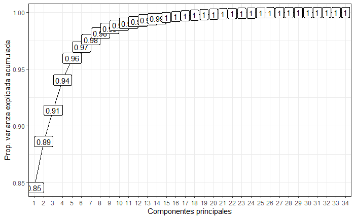

```r
pca.out3 <- prcomp(t3[,c(lista)],
                  scale. = TRUE)
#pca.out3$x
pca.var3 <- pca.out3$sdev^2  #autovalores
# Cálculo de la varianza explicada acumulada
prop_varianza <- pca.out3$sdev^2/sum(pca.out3$sdev^2)
prop_varianza_acum <- cumsum(prop_varianza)
ggplot(data = data.frame(prop_varianza_acum, pc = factor(1:34)),
       aes(x = pc, y = prop_varianza_acum, group = 1)) +
  geom_point() +
  geom_line() +
  geom_label(aes(label = round(prop_varianza_acum,2))) +
  theme_bw() +
  labs(x = "Componentes principales",
       y = "Prop. varianza explicada acumulada")
```

### Regresion logística binomial con PCA para obtener coeficientes de Confusoras

```r
#disable scientific notation for model summary
options(scipen=999)

#pca.var3
misdatos2 <- data.frame(A = t3[, "A"], pca.out3$x[, 1:2])

#pca.out3[1]
logRegPCANoExp <- glm(A ~ .,  data = misdatos2, family = binomial)

#summary(logRegPCA)
logistic.regression.or.ci(logRegPCANoExp)
```

```
$regression.table

Call:
glm(formula = A ~ ., family = binomial, data = misdatos2)

Coefficients:
            Estimate Std. Error z value Pr(>|z|)
(Intercept)  1.15736    0.33248   3.481   0.0005 ***
PC1         -0.01500    0.06277  -0.239   0.8111
PC2          0.09316    0.28461   0.327   0.7434
---
Signif. codes:  0 ‘***’ 0.001 ‘**’ 0.01 ‘*’ 0.05 ‘.’ 0.1 ‘ ’ 1

(Dispersion parameter for binomial family taken to be 1)

    Null deviance: 55.108  on 49  degrees of freedom
Residual deviance: 54.943  on 47  degrees of freedom
AIC: 60.943

Number of Fisher Scoring iterations: 4


$intercept.ci
[1] 0.5057146 1.8090041

$slopes.ci
           [,1]      [,2]
[1,] -0.1380227 0.1080163
[2,] -0.4646701 0.6509982

$OR
      PC1       PC2
0.9851087 1.0976418

$OR.ci
          [,1]     [,2]
[1,] 0.8710789 1.114066
[2,] 0.6283423 1.917454
```

```r
summary(logRegPCANoExp)$coefficients
```

```
               Estimate Std. Error    z value     Pr(>|z|)
(Intercept)  1.15735931 0.33247791  3.4810111 0.0004995247
PC1         -0.01500324 0.06276621 -0.2390337 0.8110794229
PC2          0.09316403 0.28461449  0.3273341 0.7434152053
```

```r
pscl::pR2(logRegPCANoExp)["McFadden"]
```

```
fitting null model for pseudo-r2
  McFadden
0.00298859
```

```r
caret::varImp(logRegPCANoExp)
```

|  | Overall |
| --- | --- |
| PC1 | 0.2390337 |
| PC2 | 0.3273341 |

```r
car::vif(logRegPCANoExp)
```

```
     PC1      PC2
1.000001 1.000001
```

```r
# Probar con regresion logística robusto a traves del método BY, y verificar valores con regresion normal
library(robustbase)
library(survival)
# str(t3)
datglmrob<-glmrob(formula = A ~ ., data= misdatos2, family = "binomial", method = "BY")
```

```
Convergence Achieved
```

```r
summary(datglmrob)
```

```
Call:  glmrob(formula = A ~ ., family = "binomial", data = misdatos2,      method = "BY")


Coefficients:
            Estimate Std. Error z value Pr(>|z|)
(Intercept)  1.15614    0.33192   3.483 0.000496 ***
PC1         -0.01542    0.07857  -0.196 0.844411
PC2          0.07934    0.22863   0.347 0.728580
---
Signif. codes:  0 ‘***’ 0.001 ‘**’ 0.01 ‘*’ 0.05 ‘.’ 0.1 ‘ ’ 1
Robustness weights w.r * w.x:
integer(0)

Number of observations: 0
Fitted by method ‘BY’  (in 5 iterations)

(Dispersion parameter for  family taken to be 1)

No deviance values available
Algorithmic parameters:
const
  0.5
maxhalf   maxit
     10    1000
```

```r
# Extract the variance-covariance matrix
var_cov_matrix <- vcov(datglmrob)
print(var_cov_matrix)
```

```
              [,1]         [,2]          [,3]
[1,]  0.1101740565 -0.001349642 -0.0009185936
[2,] -0.0013496417  0.006173662  0.0047904317
[3,] -0.0009185936  0.004790432  0.0522705289
```

```r
# Extract the variances of the parameter estimates
parameter_variances <- diag(var_cov_matrix)
print(parameter_variances)
```

```
[1] 0.110174057 0.006173662 0.052270529
```

```r
#              [,1]         [,2]          [,3]
#[1,]  0.1101740565 -0.001349642 -0.0009185936
#[2,] -0.0013496417  0.006173662  0.0047904317
#[3,] -0.0009185936  0.004790432  0.0522705289
```

```r
##------Comparación de coeficientes-------
datglmrob$coefficients
```

```
(Intercept)         PC1         PC2
 1.15613748 -0.01542028  0.07933723
```

```r
logRegPCANoExp$coefficients
```

```
(Intercept)         PC1         PC2
 1.15735931 -0.01500324  0.09316403
```

#### Generación Propensity Z Score

```r
############## PARA SUJETOS DE CONTROL #######################
zscores2<-c()
for(i in 1:50) {       # for-loop over rows
    zscores2[i] <-((1/(1+exp(-(as.numeric(unlist(logRegPCANoExp$coefficients[1]))+as.numeric(unlist(logRegPCANoExp$coefficients[2]))*as.numeric(unlist(pca.out3$x[i,"PC1"]))+as.numeric(unlist(logRegPCANoExp$coefficients[3]))*as.numeric(unlist(pca.out3$x[i,"PC2"])))))))
}
t3$zscore <-zscores2
quantile(t3$zscore)
```

```
       0%       25%       50%       75%      100%
0.6845395 0.7449761 0.7594602 0.7728350 0.8143427
```

```r
#       0%       25%       50%       75%      100%
#0.6845395 0.7449761 0.7594602 0.7728350 0.8143427
```

### Piece-wice constant function - Aproximar λ(Zi) usando histogram splines

```r
# Utilizar cuantiles para armar stratos que divide en 5 en rangos el histograma de "zscore" a utilizar en regresion logística

cuantil <-quantile(t3$zscore, prob = seq(0, 1, 1/5))
t3$subclass <- cut(x=t3$zscore,
                              breaks=quantile(cuantil,
                              prob = seq(0, 1, 1/5)),include.lowest=T)
levels(t3$subclass) <- 1:length(levels(t3$subclass))

xtabs(~A+subclass,t3)
```

```
   subclass
A   1 2 3 4 5
  0 2 4 2 3 1
  1 8 6 8 7 9
```

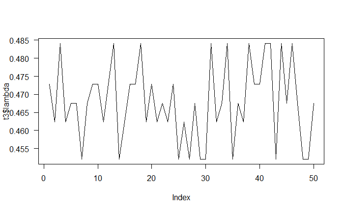

```r
# utilizar los quintiles y definir los valores medios
b1 = mean(as.numeric(unlist(dplyr::select(dplyr::filter(t3, subclass == 1,),"zscore"))))
b2 = mean(as.numeric(unlist(dplyr::select(dplyr::filter(t3, subclass == 2,),"zscore"))))
b3 = mean(as.numeric(unlist(dplyr::select(dplyr::filter(t3, subclass == 3,),"zscore"))))
b4 = mean(as.numeric(unlist(dplyr::select(dplyr::filter(t3, subclass == 4,),"zscore"))))
b5 = mean(as.numeric(unlist(dplyr::select(dplyr::filter(t3, subclass == 5,),"zscore"))))

# Determinar los valores representativos
α_1 = exp(-b1)
α_2 = exp(-b2)
α_3 = exp(-b3)
α_4 = exp(-b4)
α_5 = exp(-b5)

### Obtengo los límites de zscore a partir del filtro subclase y utilizar en la función por partes

lim1 <- max(as.numeric(unlist(dplyr::select(dplyr::filter(t3, subclass == 1,),"zscore"))))
lim2 <- max(as.numeric(unlist(dplyr::select(dplyr::filter(t3, subclass == 2,),"zscore"))))
lim3 <- max(as.numeric(unlist(dplyr::select(dplyr::filter(t3, subclass == 3,),"zscore"))))
lim4 <- max(as.numeric(unlist(dplyr::select(dplyr::filter(t3, subclass == 4,),"zscore"))))
lim5 <- max(as.numeric(unlist(dplyr::select(dplyr::filter(t3, subclass == 5,),"zscore"))))

# Armo funcion INDICADORA de x I(x ∈ lim..)
fx <- function(x, dat){
    f <- NULL
    ifelse (x > 0 & x<= lim1, f <- α_1, 0)
    ifelse (x>lim1 & x<=lim2, f <- α_2, 0)
    ifelse (x>lim2 & x<=lim3, f <- α_3, 0)
    ifelse (x>lim3 & x<=lim4, f <- α_4, 0)
    ifelse (x>lim4, f <- α_5, 0)
    f
}

x <- data.frame(t3$zscore)
for(i in 1:nrow(x)) {       # for-loop over rows
  lambd <- fx(t3$zscore[[i]])
  t3$lambda[i] <- lambd
}

plot(t3$lambda, type="l", las=1)
points(x)
```

```r
# Coeficientes b = media y α = exp(-b) // Utilizo α como coeficientes de funcion λ
c(b1, b2, b3, b4, b5)
```

```
[1] 0.7253579 0.7489343 0.7603540 0.7713493 0.7940045
```

```r
c(α_1, α_2, α_3, α_4, α_5)
```

```
[1] 0.4841512 0.4728702 0.4675009 0.4623888 0.4520310
```

```r
#[1] 0.7253579 0.7489343 0.7603540 0.7713493 0.7940045
#[1] 0.4841512 0.4728702 0.4675009 0.4623888 0.4520310
```

### Ajustar con MLE (Maximum Likelihood Estimation) λ(Zi)

Buscamos ajustar los coeficientes obtenidos en la función Lambda (función constante por partes a partir de histogram splines) que son los α_1…α_k

```r
library(stats4) # para la función mle
library(bbmle) # para la función mle2


# cuales son los pasos que necesitamos hacer para ajustar como problema MLE?
# 1 Pull out the design matrix for the model
# 2 - write support function/ NLL calculator
# 3 decide on some starting values for numerical optimization
# 4 - fit the model !! (Decide on our "black box" for optimitation method)
# 5 - check the model fit, and whether it converged..(profile)
# 6 - confirm the results do not depend on the starting values.
# If the model has not converged.. then what?
  # - change starting values
   # try different optimization method("SANN" or Nelder-Mead)

# Step 1 get the design matrix
 #- armo nuevo data frame con armado de features a partir de las subclases


design_matrix <- model.matrix(~ subclass, data=t3)
head(design_matrix)
```

```
  (Intercept) subclass2 subclass3 subclass4 subclass5
1           1         1         0         0         0
2           1         0         0         1         0
3           1         0         0         0         0
4           1         0         0         1         0
5           1         0         1         0         0
6           1         0         1         0         0
```

```r
# Utilizo además https://biol607.github.io/2012/ Exercise 14 on if (sigma <= 0) return(NaN)
# 2 - write support function/ NLL calculator

# Forma 1

glm_MLE_support <- function(b0, b1, b2, b3, b4, sigma, y = as.numeric(t3$subclass), X=design_matrix, dat =t3$zscore){
  deterministic_part <- as.numeric(ifelse((X[,2]+X[,3]+X[,4]+X[,5])==1,0,b0*X[,1]*dat) + b1*X[,2]*dat + b2*X[,3]*dat + b3*X[,4]*dat + b4*X[,5]*dat)
  if (sigma <= 0) return(NaN)
  -sum(dnorm(y, mean = as.numeric(deterministic_part), sd=as.numeric(sigma), log=T))
}

# glm_MLE_support(1,1,1,1,0,1,0.7441488)
# 3 decide on some starting values for numerical optimization

# let's use the standard error of the mean for sigma
SE <- function(x){
  as.numeric(sd(as.numeric(x))/sqrt(as.numeric(length(x))))}

# Forma2
glm.MLE.fit <- mle2(glm_MLE_support,
                    start=list(b0=α_1 , b1=α_2, b2=α_3, b3=α_4, b4=α_5, sigma = SE(t3$zscore)))
#
summary(glm.MLE.fit)
```

```
Maximum likelihood estimation

Call:
mle2(minuslogl = glm_MLE_support, start = list(b0 = α_1, b1 = α_2,
    b2 = α_3, b3 = α_4, b4 = α_5, sigma = SE(t3$zscore)))

Coefficients:
       Estimate Std. Error  z value                 Pr(z)
b0    1.3779501  0.0139718  98.6234 < 0.00000000000000022 ***
b1    2.6703470  0.0135351 197.2911 < 0.00000000000000022 ***
b2    3.9454824  0.0133320 295.9410 < 0.00000000000000022 ***
b3    5.1855838  0.0131419 394.5854 < 0.00000000000000022 ***
b4    6.2961919  0.0127660 493.1989 < 0.00000000000000022 ***
sigma 0.0320563  0.0032093   9.9886 < 0.00000000000000022 ***
---
Signif. codes:  0 ‘***’ 0.001 ‘**’ 0.01 ‘*’ 0.05 ‘.’ 0.1 ‘ ’ 1

-2 log L: -202.2084
```

```r
glm.MLE.Null <- mle2(glm_MLE_support,
                    start=list(b0 = α_1 , b1=α_2, b2=α_3, b3=α_4, b4=α_5, sigma = SE(t3$zscore)),
                    fixed=list(b0=0 , b1=0, b2=0, b3=0, b4=0))


confint(glm.MLE.Null)
```

```
Profiling...
```

```
   2.5 %   97.5 %
2.759502 4.090355
```

```r
confint(glm.MLE.fit)
```

```
Profiling...
```

```
           2.5 %     97.5 %
b0    1.35004450 1.40585312
b1    2.64331527 2.69737921
b2    3.91885950 3.97211217
b3    5.15934126 5.21183438
b4    6.27069966 6.32169160
sigma 0.02665457 0.03950779
```

```r
anova(glm.MLE.fit, glm.MLE.Null)
```

```
Likelihood Ratio Tests
Model 1: glm.MLE.fit, [glm_MLE_support]: b0+b1+b2+b3+b4+sigma
Model 2: glm.MLE.Null, [glm_MLE_support]: sigma
  Tot Df Deviance Chisq Df            Pr(>Chisq)
1      6  -202.21
2      1   261.79   464  5 < 0.00000000000000022 ***
---
Signif. codes:  0 ‘***’ 0.001 ‘**’ 0.01 ‘*’ 0.05 ‘.’ 0.1 ‘ ’ 1
```

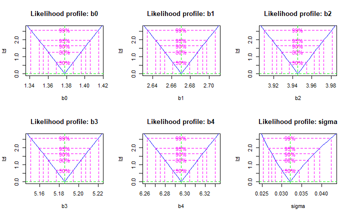

```r
# anova(str(glm.MLE.fit), test="Chisq") no funciona con este tipo de funcion nll

plot(profile(glm.MLE.fit))
```

```r
summary(glm.MLE.fit)
```

```
Maximum likelihood estimation

Call:
mle2(minuslogl = glm_MLE_support, start = list(b0 = α_1, b1 = α_2,
    b2 = α_3, b3 = α_4, b4 = α_5, sigma = SE(t3$zscore)))

Coefficients:
       Estimate Std. Error  z value                 Pr(z)
b0    1.3779501  0.0139718  98.6234 < 0.00000000000000022 ***
b1    2.6703470  0.0135351 197.2911 < 0.00000000000000022 ***
b2    3.9454824  0.0133320 295.9410 < 0.00000000000000022 ***
b3    5.1855838  0.0131419 394.5854 < 0.00000000000000022 ***
b4    6.2961919  0.0127660 493.1989 < 0.00000000000000022 ***
sigma 0.0320563  0.0032093   9.9886 < 0.00000000000000022 ***
---
Signif. codes:  0 ‘***’ 0.001 ‘**’ 0.01 ‘*’ 0.05 ‘.’ 0.1 ‘ ’ 1

-2 log L: -202.2084
```

```r
confint(glm.MLE.fit)
```

```
Profiling...
```

```
           2.5 %     97.5 %
b0    1.35004450 1.40585312
b1    2.64331527 2.69737921
b2    3.91885950 3.97211217
b3    5.15934126 5.21183438
b4    6.27069966 6.32169160
sigma 0.02665457 0.03950779
```

```r
AIC(glm.MLE.fit)
```

```
[1] -190.2084
```

```r
AIC(glm.MLE.Null)
```

```
[1] 263.7886
```

```r
# Para hacer despues, ploteo correcto https://stackoverflow.com/questions/57153916/how-do-i-plot-a-mle2-fit-of-a-model-in-ggplot2-along-with-the-data
# la busqueda en google fue ggplot(profile(mle2))
# ggplot(profile(glm.MLE.fit_1))
#5 look at fit
#library(arulesViz) no es necesario
#library(Rgraphviz) no es necesario
# dismo::plot no es necesario
################################
# Probando los coeficientes
glm.MLE.fit <- mle2(glm_MLE_support,
                    start=list(b0=1.3779501  , b1=2.6703470  , b2=3.9454824  , b3=5.1855838  , b4=6.2961919  , sigma = 0.0320563  ))
summary(glm.MLE.fit)
```

```
Maximum likelihood estimation

Call:
mle2(minuslogl = glm_MLE_support, start = list(b0 = 1.3779501,
    b1 = 2.670347, b2 = 3.9454824, b3 = 5.1855838, b4 = 6.2961919,
    sigma = 0.0320563))

Coefficients:
       Estimate Std. Error  z value                 Pr(z)
b0    1.3779501  0.0139718  98.6233 < 0.00000000000000022 ***
b1    2.6703470  0.0135351 197.2910 < 0.00000000000000022 ***
b2    3.9454824  0.0133320 295.9409 < 0.00000000000000022 ***
b3    5.1855838  0.0131419 394.5852 < 0.00000000000000022 ***
b4    6.2961919  0.0127660 493.1987 < 0.00000000000000022 ***
sigma 0.0320563  0.0032093   9.9886 < 0.00000000000000022 ***
---
Signif. codes:  0 ‘***’ 0.001 ‘**’ 0.01 ‘*’ 0.05 ‘.’ 0.1 ‘ ’ 1

-2 log L: -202.2084
```

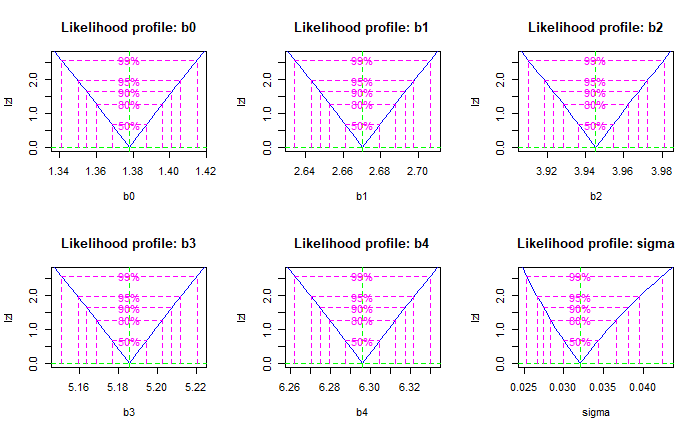

```r
plot(profile(glm.MLE.fit))
```

```r
### Se logra con la reg logistica entre A y lambda(z)
glm.MLE.fit
```

```
Call:
mle2(minuslogl = glm_MLE_support, start = list(b0 = 1.3779501,
    b1 = 2.670347, b2 = 3.9454824, b3 = 5.1855838, b4 = 6.2961919,
    sigma = 0.0320563))

Coefficients:
       b0        b1        b2        b3        b4     sigma
1.3779501 2.6703470 3.9454824 5.1855838 6.2961919 0.0320563

Log-likelihood: 101.1
```

```r
# δ<-deviance(glm.MLE.fit)/df.residual(glm.MLE.fit) # ratio varianza para Delta
# delta <-deviance(reg)/df.residual(reg)
```

### Armar Estratos de Z score para todos los datos y obtener δ -> D=1~δA+λ(Zi)

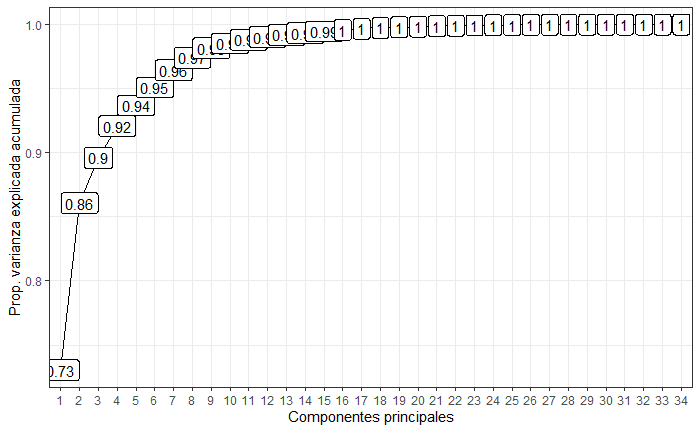

```r
t2 <- dplyr::select(dplyr::filter(t, label == 0), "sl2l_qa", "sl2l_iso", "ccbd_iso", "ccbd_qa", "ifol_qa", "ifol_iso", "ecpl_qa", "ecpl_iso", "tral_qa", "tral_iso", "afsl_qa", "afsl_iso", "afsr_qa", "afsr_iso", "cfpl_iso", "cfpl_qa", "cfpr_iso", "cfpr_qa", "fatl_iso", "fatl_qa", "fatr_iso", "fatr_qa", "slfl_iso", "slfl_qa", "slfr_iso", "slfr_qa", "tral_iso", "tral_qa", "ufsl_iso", "ufsl_qa", "ufsr_iso", "ufsr_qa", "age", "gend_F", "A")

pca.out2 <- prcomp(t2[,c(lista)],
                  scale. = TRUE)
#pca.out3$x
pca.var2 <- pca.out2$sdev^2  #autovalores
# Cálculo de la varianza explicada acumulada
prop_varianza1 <- pca.out2$sdev^2/sum(pca.out2$sdev^2)
prop_varianza_acum1 <- cumsum(prop_varianza1)
ggplot(data = data.frame(prop_varianza_acum1, pc = factor(1:34)),
       aes(x = pc, y = prop_varianza_acum1, group = 1)) +
  geom_point() +
  geom_line() +
  geom_label(aes(label = round(prop_varianza_acum1,2))) +
  theme_bw() +
  labs(x = "Componentes principales",
       y = "Prop. varianza explicada acumulada")
```

```r
NA
NA
```

```r
############## ESTRATIFICACION PARA SUJETOS DE ESTUDIO #######################
zscores3<-c()
for(i in 1:46) {       # for-loop over rows
    zscores3[i] <-((1/(1+exp(-(as.numeric(unlist(logRegPCANoExp$coefficients[1]))+as.numeric(unlist(logRegPCANoExp$coefficients[2]))*as.numeric(unlist(pca.out2$x[i,"PC1"]))+as.numeric(unlist(logRegPCANoExp$coefficients[3]))*as.numeric(unlist(pca.out2$x[i,"PC2"])))))))
}
t2$zscore <-zscores3
quantile(t2$zscore)
```

```
       0%       25%       50%       75%      100%
0.6827195 0.7332740 0.7584268 0.7858424 0.8351614
```

```r
# Utilizar cuantiles para armar stratos que divide en 5 en rangos el histograma de "zscore" a utilizar en regresion logística

cuantil <-quantile(t2$zscore, prob = seq(0, 1, 1/5))
t2$subclass <- cut(x=t2$zscore,
                              breaks=quantile(cuantil,
                              prob = seq(0, 1, 1/5)),include.lowest=T)
levels(t2$subclass) <- 1:length(levels(t2$subclass))

xtabs(~A+subclass,t2)
```

```
   subclass
A    1  2  3  4  5
  0  0  0  0  2  1
  1 10  9  9  7  8
```

```r
############## UNIR DATOS PARA REG LOG CONDICIONAL #######################
t3$D <- 0 #Sujetos de Control
t2$D <- 1 #Sujetos de Estudio
dat <- rbind(t3[,c("D","subclass","A")], t2[,c("D","subclass","A")])
```

```r
library(survival)
# Regresion logística condicional o por estratos
reglog.cond <-clogit(D~A+strata(subclass),data=dat)
summary(reglog.cond)
```

```
Call:
coxph(formula = Surv(rep(1, 96L), D) ~ A + strata(subclass),
    data = dat, method = "exact")

  n= 96, number of events= 46

    coef exp(coef) se(coef)     z Pr(>|z|)
A 1.4773    4.3809   0.6792 2.175   0.0296 *
---
Signif. codes:  0 ‘***’ 0.001 ‘**’ 0.01 ‘*’ 0.05 ‘.’ 0.1 ‘ ’ 1

  exp(coef) exp(-coef) lower .95 upper .95
A     4.381     0.2283     1.157     16.58

Concordance= 0.587  (se = 0.037 )
Likelihood ratio test= 5.75  on 1 df,   p=0.02
Wald test            = 4.73  on 1 df,   p=0.03
Score (logrank) test = 5.38  on 1 df,   p=0.02
```

```r
delta = coefficients(reglog.cond)[[1]]
```

### Armar la estructura de datos en D, A, λ(Zi)

### Forma de hallar Coeficientes con Regresion Logistica Parcial D=1~A+λ(Zi)

Esta parte, en base a la estructura del paper, se utiliza para hallar intercept y coeficientes, luego ajustar con MLL, hacer bootstrap y generar posibles varianzas asintóticas de los coeficientes. Con el valor de la varianza asintotica del feature A es posible comparar con el coeficiente logrado en reg logística estratificada (condicional) propuesto.

```r
# 1. Prefix -------------------------------------------------------------------

# Loading packages
require(optimx)
require(numDeriv)
require(dplyr)

# 2. Loading dataset ----------------------------------------------------------
t3$D <- 0
X = model.matrix(~subclass, data=t3) # Armo matriz de dummies para coeficientes

dat <- t3$zscore  # valores de zscore a utilizar en la función lambda
b0 <- 1.3779501 # coef 1 - Intercept
b1 <- 2.6703470 # coef 2
b2 <- 3.9454824 # coef 3
b3 <- 5.1855838 # coef 4
b4 <- 6.2961919 # coef 5

# Funcion lambda (funcion constante por partes) para obtener coeficiente de feature propensity zscore
λzi <- (as.numeric(ifelse((X[,2]+X[,3]+X[,4]+X[,5])==1,0,b0*X[,1]*dat) + b1*X[,2]*dat + b2*X[,3]*dat + b3*X[,4]*dat + b4*X[,5]*dat))

# 3. Define log-likelihood function for logistic regression model -------------
# (see applied logistic regression)
negll <- function(par){

  #Extract guesses for alpha and beta1
  alpha <- par[1]
  beta1 <- par[2]
  beta2 <- par[3]

  #Define dependent and independent variables
  y  <- t3$D
  x1 <- t3$A
  x2 <- λzi

  #Calculate pi and xb
  xb <- alpha + beta1 * x1 + beta2 * x2
  pi <- exp(xb) / (1 + exp(xb))

  #Set high values for 0 < pi < 1
  if(any(pi > 1) | any(pi < 0)) {
    val <- 1e+200
  } else {
    val <- -sum(y * log(pi) + (1 - y) * log(1 - pi))
  }
  val
}

# 4. Define Gradient function for logistic regression model -------------------
# (see applied logistic regression)
negll.grad <- function(par){

  #Extract guesses for alpha and beta1
  alpha <- par[1]
  beta1 <- par[2]
  beta2 <- par[3]

  #Define dependent and independent variables
  y  <- t3$D
  x1 <- t3$A
  x2 <- λzi

  #Create output vector
  n <- length(par[1])
  gg <- as.vector(rep(0, n))

  #Calculate pi and xb
  xb <- alpha + beta1 * x1 + beta2 * x2
  pi <- exp(xb) / (1 + exp(xb))

  #Calculate gradients for alpha and beta1
  gg[1] <- -sum(y - pi)
  gg[2] <- -sum(x1 * (y - pi))
  gg[3] <- -sum(x2 * (y - pi))

  return(gg)
}

# 4.1 Compare gradient function with numeric approximation of gradient ========
# compare gradient at 0, 0, 0
mygrad <- negll.grad(c(0, 0, 0))
numgrad <- grad(x = c(0, 0, 0), func = negll)

all.equal(mygrad, numgrad)
```

```
[1] TRUE
```

```r
# 4. Find maximum of log-likelihood function ----------------------------------
opt <- optimx(par = c(alpha  = 0,
                      beta_1 = 0,
                      beta_2 = 0),
              fn = negll,
              gr = negll.grad,
              control = list(trace = 0,
                             all.methods = TRUE))
# print reulsts of optimisation
# remove not needed information for purpose of presentation
summary(opt, order = "convcode") %>%
  dplyr::select(-value, -fevals, -gevals ,-niter )
```

|  | alpha | beta_1 | beta_2 | convcode | kkt1 | kkt2 | xtime |
| --- | --- | --- | --- | --- | --- | --- | --- |
| BFGS | -25.00000 | -19.000000 | -74.99243 | 0 | TRUE | FALSE | 0 |
| CG | -25.00000 | -19.000000 | -74.99243 | 0 | TRUE | FALSE | 0 |
| Nelder-Mead | 24.48889 | 11.111111 | -79.24444 | 0 | TRUE | FALSE | 0 |
| L-BFGS-B | -12.33751 | -2.461278 | -8.80537 | 0 | TRUE | TRUE | 0 |
| nlm | -25.00000 | -19.000000 | -74.99243 | 0 | TRUE | FALSE | 0 |
| Rcgmin | -30.00000 | -22.800000 | -89.99091 | 0 | TRUE | FALSE | 0 |
| nlminb | -106.31555 | 10.185020 | 11.34241 | 1 | TRUE | FALSE | 0 |
| Rvmmin | -25.00000 | -19.000000 | -74.99243 | 2 | TRUE | FALSE | 0 |
| spg | NA | NA | NA | 9999 | NA | NA | 0 |
| ucminf | NA | NA | NA | 9999 | NA | NA | 0 |

[output cut: 4 more lines]

```r
#value fevals gevals niter
# 5. Estimate regression coeficents using glm ---------------------------------

glm_model <- glm(D ~ A + λzi,
                 data = t3,
                 family = binomial(link = "logit"))

# Print coefficents
coef(glm_model)
```

```
              (Intercept)                         A                       λzi
-26.566068523538358903124   0.000000000000003090894   0.000000000000005301978
```

```r
# 6. Comparing results from optimx and glm ------------------------------------
glm_results <- unname(coef(glm_model))
coef_opt <- coef(opt)

lapply(1:nrow(coef_opt), function(i){

    optimisation_algorithm <- attributes(coef_opt)$dimnames[[1]][i]

    mle_glm1 <- (coef_opt[i, "alpha" ] - glm_results[1])
    mle_glm2 <- (coef_opt[i, "beta_1"] - glm_results[2])
    mle_glm3 <- (coef_opt[i, "beta_2"] - glm_results[3])

    mean_difference <- mean(mle_glm1, mle_glm2, mle_glm3, na.rm = TRUE)

    data.frame(optimisation_algorithm, mean_difference)

  }) %>%
    bind_rows() %>%
  filter(!is.na(mean_difference)) %>%
  mutate(mean_difference = abs(mean_difference)) %>%
  arrange(mean_difference)
```

| optimisation_algorithm | mean_difference |
| --- | --- |
| BFGS | 1.566069 |
| CG | 1.566069 |
| nlm | 1.566069 |
| Rvmmin | 1.566069 |
| Rcgmin | 3.433931 |
| L-BFGS-B | 14.228557 |
| Nelder-Mead | 51.054957 |
| nlminb | 79.749484 |

```r
####################################################################################################
# https://arunaddagatla.medium.com/maximum-likelihood-estimation-in-logistic-regression-f86ff1627b67
# https://www.joshua-entrop.com/post/optim_logit_reg/
# https://stats.stackexchange.com/questions/568322/students-t-distribution-and-ml-in-
# https://rpubs.com/ramblinguy/meh
####################################################################################################
# Lugares consultados en general
# https://www.youtube.com/watch?v=wPtHpEp-jRo
# https://stackoverflow.com/questions/32567582/asymptotic-variance-of-maximum-likelihood-estimator-with-optim-in-r
# https://rstudio-pubs-static.s3.amazonaws.com/415830_829dd2b0150d438894c0e6695e7e6721.html
# https://statisticalhorizons.com/logistic-regression-for-rare-events/
# http://www.sthda.com/english/articles/36-classification-methods-essentials/149-penalized-logistic-regression-essentials-in-r-ridge-lasso-and-elastic-net/
# https://www.analyticsvidhya.com/blog/2018/07/introductory-guide-maximum-likelihood-estimation-case-study-r/
# https://stackoverflow.com/questions/24811598/error-in-dropy-rep1-nc-error-for-cv-glmnet-in-glmnet-r-package
#
# https://rpubs.com/vanessa1217/645522   Proyecto Final Big Data
# https://stats.stackexchange.com/questions/219828/interpretation-of-coefficients-in-logistic-regression-output
# https://tidystat.com/meaning-of-hessian-matrix-from-optim-in-r/
#
####################################################################################################
```

#### Generar Constante Delta δ -> D=1~δA+λ(Zi) a Partir del MLL Reg Log Parcial

Generado despues de obtener la regresion logistica parcial del modelo final

```r
# attr(opt, "details")["L-BFGS-B" ,"nhatend"][[1]]
# Extract the Hessian matrix
hessian <- attr(opt, "details")["L-BFGS-B" ,"nhatend"][[1]]

# Calculate the asymptotic variance-covariance matrix
n <- length(t3)
avar_cov <- solve(hessian) / n


# Extract the asymptotic variances
asymptotic_variances <- diag(avar_cov)
asymptotic_variances
```

```
[1] 28984544737    78658624 29297330587
```

```r
# Print the results
print(asymptotic_variances)
```

```
[1] 28984544737    78658624 29297330587
```

```r
# Calculate the asymptotic variance ratios
avar_ratios <- matrix(NA, nrow = 3, ncol = 3)
rownames(avar_ratios) <- c("d1","d2","d3") # names(asymptotic_variances)
colnames(avar_ratios) <- c("d1","d2","d3") # names(asymptotic_variances)

for (i in 1:3) {
  for (j in 1:3) {
    avar_ratios[i, j] <- asymptotic_variances[i] / asymptotic_variances[j]
  }
}

# Print the result
print(avar_ratios)
```

```
            d1       d2          d3
d1 1.000000000 368.4853 0.989323742
d2 0.002713813   1.0000 0.002684839
d3 1.010791470 372.4618 1.000000000
```

Interpretación de resultados de ratios de la varianza:

- El elemento fuera de la diagonal más grande es 372.46, que representa la relación entre la varianza asintótica de param3(d3) y la varianza asintótica de param2 (d2). Esto indica que d3 se estima con mucha menos precisión en comparación con d2
- El elemento fuera de la diagonal más pequeño es 0.0026, que representa la relación entre la varianza asintótica de d2 y la varianza asintótica de d3. Esto sugiere que d2 se estima con mayor precisión en comparación con d3.
- d1 y d3 tienen una relación cercana a 1 (0.99 y 1.01), lo que indica niveles similares de precisión en sus estimaciones.
- Al interpretar la matriz de relación de varianza asintótica en el contexto de su problema específico y combinarla con otros diagnósticos del modelo, puede obtener información valiosa sobre la precisión relativa de las estimaciones de sus parámetros e identificar áreas potenciales para una mayor investigación o refinamiento del modelo.

```r
# Set the sample size
n <- 100

# A partir del mejor MLL con metodo L-BFGS-B
# Define the true parameter values
beta0 <- -12.33751   # Intercept
beta1 <- -2.461278  # Coefficient for X1
beta2 <- -8.80537 # Coefficient for X2

# Generate the predictor variables
X1 <- rbinom(n, size = 1, prob = 0.5)
X2 <- rnorm(n, mean = 0, sd = 1)

# Calculate the linear predictor
linear_predictor <- beta0 + beta1 * X1 + beta2 * X2

# Generate the binary response variable (Y) from the binomial distribution
Y <- rbinom(n, size = 1, prob = plogis(linear_predictor))

# Combine the variables into a data frame
synthetic_data <- data.frame(X1, X2, Y)
```

### Resampling approach with boostrap, para reg log estratificada y obtener varianza

Puedo combinar la simulación de Monte Carlo y los métodos de arranque para evaluar exhaustivamente el rendimiento de los estimadores y estimar la variabilidad de las estadísticas. La simulación de Monte Carlo permite evaluar el comportamiento de los estimadores en varios escenarios, mientras que los métodos de arranque proporcionan una manera de estimar la variabilidad de las estadísticas y aproximar sus distribuciones muestrales.

```r
# Load the package
library(boot)
library(survival)

# Set the sample size
n <- 100

# A partir del mejor MLL con metodo L-BFGS-B
# Define the true parameter values
beta0 <- -12.33751   # Intercept
beta1 <- -2.461278  # Coefficient for X1
beta2 <- -8.80537 # Coefficient for X2

# Generate the predictor variables
X1 <- rbinom(n, size = 1, prob = 0.5)
X2 <- rnorm(n, mean = 0, sd = 1)

# Calculate the linear predictor
linear_predictor <- beta0 + beta1 * X1 + beta2 * X2

# Generate the binary response variable (Y) from the binomial distribution
Y <- rbinom(n, size = 1, prob = plogis(linear_predictor))

# Combine the variables into a data frame
synthetic_data <- data.frame(X1, X2, Y)

stat_func <- function(t, indices) {
  # Calculate the statistic on the resampled data
  #Regresion logística condicional o por estratos
  d <- t[indices, ]
  rlog<- glm(Y ~ X1 + X2,  #D ~ A + λzi,
                 data = d,
                 family = binomial)
  deviance(rlog)/df.residual(rlog)
}

# Set the number of Monte Carlo simulations
n_sims <- 1000

# Initialize vectors to store the results
estimates <- numeric(n_sims)

# Run the Monte Carlo simulations
for (i in 1:n_sims) {
  # Generate synthetic data based on a known model or process
  datas <- synthetic_data #generate_data(...)

  # Perform bootstrapping
  boot_output <- boot(data = datas, statistic = stat_func, R = 100)

  # Access the bootstrap results
  boot_estimates <- boot_output$t0  # Bootstrap estimates of the statistic

  # Apply the estimator or method of interest
  estimates[i] <- boot_estimates #estimate_parameter(data)
}

# Evaluate the performance of the estimator
mean_estimate <- mean(estimates)
estimates
bias <- mean_estimate - true_parameter_value
variance <- var(estimates)
mse <- mean((estimates - true_parameter_value)^2)
```

### Resampling approach with boostrap, para reg log estratificada y obtener varianza

```r
boot_output
```

```
ORDINARY NONPARAMETRIC BOOTSTRAP


Call:
boot(data = datas, statistic = stat_func, R = 100)


Bootstrap Statistics :
      original      bias    std. error
t1* 0.06826842 -0.03413264   0.0467954
```

## Modelo Final

```r
log_Ratio_odds_sujetos_ctrl
```

```
 [1] 0.2213359 0.9817299 0.2108898 0.2273009 0.2256814 0.2257209 0.2278994 0.9526717 0.2212834 0.8829267 0.2272891
[12] 0.2213060 0.2107823 0.2278996 0.2273114 0.2214791 0.8807420 0.2108814 0.2273108 0.2214486 0.2273086 0.2256722
[23] 0.2272888 0.8813436 0.2278813 0.9824772 0.9935188 0.2256921 0.2279324 0.2278882 0.2104235 0.2273498 0.2256823
[34] 0.7320597 0.2278888 0.2257579 0.9821933 0.7280601 0.8824838 0.2213950 0.2109240 0.2105007 0.2279533 0.2106514
[45] 0.2256686 0.2096310 0.9523388 0.2279152 0.2279239 0.2257063
```

Probando con datos de sujetos estudio utilizando coeficientes de sujetos de Control

```r
δ <- delta
Xse = model.matrix(~subclass, data=t2) # Armo matriz de dummies para coeficientes

datse <- t2$zscore  # valores de zscore a utilizar en la función lambda
b0 <- 1.3779501 # coef 1 - Intercept
b1 <- 2.6703470 # coef 2
b2 <- 3.9454824 # coef 3
b3 <- 5.1855838 # coef 4
b4 <- 6.2961919 # coef 5

# Funcion lambda (funcion constante por partes) para obtener coeficiente de feature propensity zscore
λzise <- (as.numeric(ifelse((Xse[,2]+Xse[,3]+Xse[,4]+Xse[,5])==1,0,b0*Xse[,1]*datse) + b1*Xse[,2]*datse + b2*Xse[,3]*datse + b3*Xse[,4]*datse + b4*Xse[,5]*datse))
log_ODDs_Ratios_sujetos_estudio <- productoria(t2$D, δ, t2$A, λzise)

log_ODDs_Ratios_sujetos_estudio
log_Ratio_odds_sujetos_estudio = exp(t2$D*(δ*t2$A)+(λzise)) / (1+(exp((δ*t2$A)+(λzise))))
```

[output not shown]

```r
c(log_ODDs_Ratios, log_ODDs_Ratios_sujetos_estudio)
```

```
[1] 0.00000000000000000000000004388666 0.27578019801803826949182507632941
```

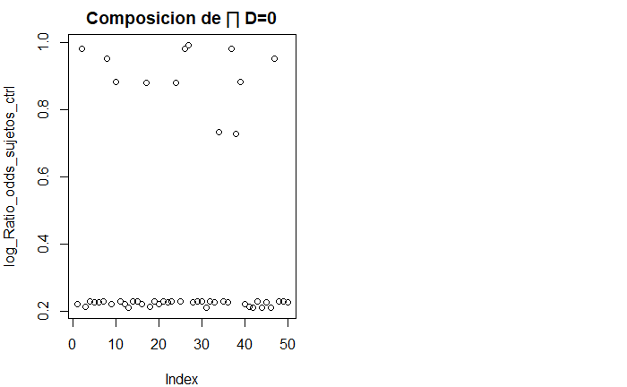

```r
par(mfrow = c(1, 2), mar = c(4, 4, 2, 1))
plot(log_Ratio_odds_sujetos_ctrl, main = "Composicion de ∏ D=0")
plot(log_Ratio_odds_sujetos_estudio, main = "Composicion de ∏ D=1")
```

[output not shown]

### Alternativas comunes a R^2 en regresión logística condicional

- **Estadística de concordancia (estadística C)** : la estadística C, también conocida como área bajo la curva característica operativa del receptor (ROC), mide la capacidad discriminativa del modelo. Va desde 0,5 (sin discriminación) a 1 (discriminación perfecta).
4. **Criterios de información** : los criterios de información, como el Criterio de información de Akaike (AIC) y el Criterio de información bayesiano (BIC), se pueden utilizar para comparar el ajuste relativo de diferentes modelos. Valores más bajos de AIC o BIC indican un mejor ajuste.

```r
performance::r2(model, adjust = TRUE) #proporción de variación explicada por los predictores
```

```
  Nagelkerke's R2: 0.083
```

```r
# Hacer graficas
# https://cran.rstudio.com/web/packages/regressinator/vignettes/logistic-regression-diagnostics.html
```